# Exploring data with `dplyr`

ENVS475: Experimental Analysis and Design

December, 2022

# Overview

This tutorial is aimed at giving you an introduction to the popular `dplyr` package. `dplyr` provides a few simple verbs that allow you to quickly and easily select and manipulate your data, and create an interactive environment for data exploration. This tutorial is based on Chapter 5 in [“*R for Data Science*”](http://r4ds.had.co.nz) by Hadley Wickham & Garrett Grolemund which is vailable for free online. Material was also adapted from the dplyr introduction vignette which you can find by running the following command:

```r
vignette("dplyr")
```

`dplyr` is part of the suite of packages known as `tidyverse`. The packages within the tidyverse were designed with a similar data and programming philosophy, and work together fluidly. Hadley Wickham is the lead developer of the tidyverse, and his book above takes a tidyverse-centric view, and is a fantastic resource if you want to learn more. We will be using the `tidyverse` packages throughout this course.

## Preliminaries

Before we begin, make sure you have the following packages installed: `dplyr`, `ggplot2` and `nycflights13`.

If you need to install `dplyr` or `nycflights13`, run the following lines of code, as needed. Also note that the package name is inside of "" in the function call:

```r
install.packages("dplyr")
install.packages("nycflights13")
```

As a reminder, you only have to run the `install.packages(...)` line once per machine. Running this line downloads the package onto the machine that you are currently using. However, you do need to load the packages at the beginning of every session. The following commands “loads” the packages and makes the commands available to you. Note that once the package is installed, you *do not* need "" around the package name.

```r
library(dplyr)
library(nycflights13)
```

### Data: nycflights13

In order to demonstrate the basic data manipulation verbs of dplyr, we will be using the `nycflights13` database. This data object contains five dataframes: `airlines`, `airports`, `flights`, `planes`, and `weather`. The `flights` dataset contains all 336776 flights that departed from New York City in 2013. The data comes from the US [Bureau of Transportation Statistics](http://www.transtats.bts.gov/DatabaseInfo.asp?DB_ID=120&Link=0), and is documented in `?nycflights13::flights`

We will load the `flights` data by running the following command:

```r
data("flights")
```

It is worth noting that this data is already in the “tidydata” format. Unfortunately, going into this in detail is beyond the scope of this tutorial, but I recommend you look at the “tidydata” chapter in R for Data Science: https://r4ds.had.co.nz/tidy-data.html. Likewise, see my plug for tidydata at the end of this document.

Whenever you start working with a new dataset, you should also run some quick commands to get an idea of what the data looks like, and how it is set up. I generally run the following commands (note that I have suppressed the display in this document for room, but you should run each of these on your computer):

```r
dim(flights)
head(flights)
tail(flights)
str(flights)
```

You may notice that the `head(flights)` output is different from many other data frames that you may have worked with before. It only shows the rows and columns that easily fit into your window. That’s because the `flights` object is a tibble:

```r
class(flights)
```

```
#> [1] "tbl_df"     "tbl"        "data.frame"
```

Tibbles `"tbl_df"` act just as a data frame would, but they print only the information that can fit into your window. To see the full data frame in the Rstudio viewer use:

```r
View(flights)
```

Or as a normal data frame use:

```r
head(as.data.frame(flights))
```

To convert a data frame to a tibble, use `as_tibble()`.

As a general rule, I almost always use the `names()` function when I’m looking at a new data set. This helps me get an idea of the data structure, and if the variable names are meaningful, can help me understand what types of questions I can ask, and how I may be able to answer them.

```r
names(flights)
```

```
#>  [1] "year"           "month"          "day"            "dep_time"
#>  [5] "sched_dep_time" "dep_delay"      "arr_time"       "sched_arr_time"
#>  [9] "arr_delay"      "carrier"        "flight"         "tailnum"
#> [13] "origin"         "dest"           "air_time"       "distance"
#> [17] "hour"           "minute"         "time_hour"
```

These variables should be relatively self-explanatory, but you can run `?flights` for more information.

# `dplyr`

Data manipulation is one of the primary tasks that scientists undertake. the `dplyr` package makes it easy to select the data you want, organize it in a useful way, calculate useful new variables, and summarize data by groups.

There is an extremely helpful Rstudio data wrangling cheat sheet which you can download directly through Rstudio by clicking *Help > Cheatsheets > Data transformation with dplyr*.

**Practice good project organization** When you download these cheatsheets, put them all in an appropriate folder so you can find them again easily. Recall that I recommend the following sub folders in your `ENVS_475` project directory:

```
ENVS_475/
  |─── other_resources/
        |─── cheatsheets/
              |─── data-transformation.pdf
```

I almost always have this cheat sheet open while I’m conducting any analyses. It takes a little effort to learn how to “read” the cheat sheet, but it’s well worth the effort.

## Single table verbs

dplyr aims to provide a function for each basic verb of data manipulation:

- Pick observations based on their values: `filter()`
- Pick observations based on their row number `slice()`
- Reorder the rows: `arrange()`
- Pick variables based on their names: `select()`
- Add new variables using functions on existing variables: `mutate()`
- Reduce many observations to a single summary: `summarise()`

All of these verbs can also be used with `group_by()`, which allows you to apply a verb group-by-group instead of on the whole data set, but more on this later.

All verbs work similarly and have similar syntaxes:

1. The first argument is a data frame.
2. Following arguments specify what to do with the data frame using un-quoted variable names.
3. Result is new data frame.

There are other verbs in the `dplyr` package, along with many useful “helper” functions. Browse the vignettes for dplyr: `browseVignettes(package = "dplyr")`, or check the Rstudio data wrangling cheat sheet which you downloaded at the beginning of this tutorial.

### Filter rows with `filter()`

`filter()` allows you to select a subset of rows in a data frame. The first argument is the name of the data frame. The second and subsequent arguments are the expressions that filter the data frame.

#### Filter rows based on numeric data

For example, we can select all flights on July 4th with:

```r
filter(flights, month == 7, day == 4)
```

```
#> # A tibble: 737 x 19
#>    year month   day dep_time sched_dep_time dep_delay arr_time sched_arr_time
#>   <int> <int> <int>    <int>          <int>     <dbl>    <int>          <int>
#> 1  2013     7     4       11           2359        12      400            340
#> 2  2013     7     4       59           2359        60      501            350
#> 3  2013     7     4      454            500        -6      635            640
#> 4  2013     7     4      535            536        -1      802            806
#> # ... with 733 more rows, and 11 more variables: arr_delay <dbl>,
#> #   carrier <chr>, flight <int>, tailnum <chr>, origin <chr>, dest <chr>,
#> #   air_time <dbl>, distance <dbl>, hour <dbl>, minute <dbl>, time_hour <dttm>
```

If you check the output of this function, you shuold notice at the top R tells us that the functioned returned “A tibble: 737 x 19”. This means that the data returned had 737 rows and 19 columns. This makes sense, because we are only asking for flights which left on a certain day, but are not changing anyhting about the number of columns. It’s always a good idea to double check that the size of the returned data makes sense.

you try it - modify the code above to filter out flights that occured in the month of July. What is the size of the returned tibble? ***

#### The use of `==`

You may have noticed in the `filter()` command we used `==` instead of `=`. The `==` is a Boolean operator. It is used to specify that we want to know if the object on the left is *exactly* the same as the object on the right. For example, run the following code:

```r
5 == 5
```

```
#> [1] TRUE
```

```r
5 == 9
```

```
#> [1] FALSE
```

```r
"A"=="a"
```

```
#> [1] FALSE
```

```r
"a" == "a"
```

```
#> [1] TRUE
```

The single `=` is another way of *assigning* a value to an object in R. For example `a = 5` stores the value of 5 inside of the object called `a`.

Other Boolean operators are discussed below, but for now, let’s get back to our `filter(flights, month == 7, day == 4)` command… This is equivalent to the standard subsetting notation in base R:

```r
flights[flights$month == 7 & flights$day == 4, ]
```

But as you can see, there’s a lot more detail that needs to be included in the base commands, and it’s much easier to make mistakes. To be honest, I *always* forget exactly how to do it, and have to Google the syntax nearly ever time I do it this way.

You may also see old scripts or tutorials using the `subset()` command. `filter()` works very similarly to `subset()` but is slightly more flexible. As far as I can tell `filter()` has superceded `subset()`, so we won’t be going over it here but I wanted to mention it in case you see it other places.

`filter()` also works with other Boolean operators, which allows for a very flexible system to filter out specific cases.

#### Other Boolean operators

Other Boolean operators include: * `|` which means “or” * `&` which means “and” * `!=` which means “not equal to” * `>=`which means “greater than or equal to” * `<=`which means “less than or not equal to” * `>`which means “greater than” * `<`which means “less than”

You can use boolean operators, singly and in combination:

```r
# flights in January OR February
filter(flights, month == 1 | month == 2)
# flights in January OR February AND that flew > 1000 OR < 500 miles
filter(flights, month == 1 | month == 2 & distance > 1000 | distance < 500)
```

Sometimes you want to see all of the data that do *not* meet a criteria. For example, maybe you don’t want to know what flights left in July. You could use a combination of arguments within `filter()` such as: `month < 7 | month > 7`, or you could use the logical negation command `!=`. This command can be read as “not equal to”.

```r
# month less than "OR" greater than 7
not_july_1 <- filter(flights, month < 7 | month >7)
# month "not equal to" 7
not_july_2 <- filter(flights, month != 7)
# are these to objects the same?
identical(not_july_1, not_july_2)
```

```
#> [1] TRUE
```

```r
# yes
```

Both lines of code above give the same result, but the second line is simpler to write, and you don’t have to remember if you’re supposed to use an “AND” (`&`) or an “OR” (`|`) command.

#### Filtering rows based on character data

In the example above, we were filtering observations based on numeric data (i.e., `month == 7` for July). Filter also works with character data types. For example, let’s extract all of the flights that were operated by United Airlines, which is abbreviated as “UA” in the `carrier` column

```r
filter(flights, carrier == "UA")
```

```
#> # A tibble: 58,665 x 19
#>    year month   day dep_time sched_dep_time dep_delay arr_time sched_arr_time
#>   <int> <int> <int>    <int>          <int>     <dbl>    <int>          <int>
#> 1  2013     1     1      517            515         2      830            819
#> 2  2013     1     1      533            529         4      850            830
#> 3  2013     1     1      554            558        -4      740            728
#> 4  2013     1     1      558            600        -2      924            917
#> # ... with 58,661 more rows, and 11 more variables: arr_delay <dbl>,
#> #   carrier <chr>, flight <int>, tailnum <chr>, origin <chr>, dest <chr>,
#> #   air_time <dbl>, distance <dbl>, hour <dbl>, minute <dbl>, time_hour <dttm>
```

Note the use of `""` around UA in the `filter()` function. Remove the quotes and run the code again. What happens?

You should have received an error code in the R console. Error codes often look like hieroglyphics the first few times you see them, but the important information in this error is the “object ‘UA’ not found”. When we enter unquoted arguments into the dplyr functions, R looks for objects (i.e., data objects, column names within a data object, etc.) with that name.

#### Removing `NA`’s with `filter()`

A common task in data analysis requires the removal of `NA` values in our data. For example, in the `flights` data, flights which were cancelled have `NA` values in the `dep_` and `arr_` columns.

Based on what we learned before it’s natural to think that we do this by using the condition `dep_time != NA` * To remove only rows with `NA` in specific columns use `filter`

```r
filter(flights, dep_time != NA)
```

```
#> # A tibble: 0 x 19
#> # ... with 19 variables: year <int>, month <int>, day <int>, dep_time <int>,
#> #   sched_dep_time <int>, dep_delay <dbl>, arr_time <int>,
#> #   sched_arr_time <int>, arr_delay <dbl>, carrier <chr>, flight <int>,
#> #   tailnum <chr>, origin <chr>, dest <chr>, air_time <dbl>, distance <dbl>,
#> #   hour <dbl>, minute <dbl>, time_hour <dttm>
```

- Why didn’t that work?
- Null values like `NA` are special
- We don’t want to accidentally say that two “missing” things are the same
  - We don’t know if they are
- So use special commands
- `is.na()` checks if the value is `NA`
- Combine this with `!` for “not”

```r
filter(flights, !is.na(dep_time))
```

```
#> # A tibble: 328,521 x 19
#>    year month   day dep_time sched_dep_time dep_delay arr_time sched_arr_time
#>   <int> <int> <int>    <int>          <int>     <dbl>    <int>          <int>
#> 1  2013     1     1      517            515         2      830            819
#> 2  2013     1     1      533            529         4      850            830
#> 3  2013     1     1      542            540         2      923            850
#> 4  2013     1     1      544            545        -1     1004           1022
#> # ... with 328,517 more rows, and 11 more variables: arr_delay <dbl>,
#> #   carrier <chr>, flight <int>, tailnum <chr>, origin <chr>, dest <chr>,
#> #   air_time <dbl>, distance <dbl>, hour <dbl>, minute <dbl>, time_hour <dttm>
```

#### Using `unique()`

It is also often useful to see all of the values that occur within a variable column. For example, what are all of the airport origins in this data set?

Here, I will use the base R function `unique()` to see all of the values in the variable “origin”. To select just that variable, I will use the `$` subsetting function.

```r
unique(flights$origin)
```

```
#> [1] "EWR" "LGA" "JFK"
```

This data contains all of the flights leaving New York City, and the codes above refer to Newark, LaGuardia, and JFK, respectively.

#### Pracice problems 1

1. Filter out all of the flights that departed in December.
2. What are all of the `carriers` in this data set? Choose one and filter out all of the flights for that carrier.
3. Filter out all of the flights that did *not* depart on the 13th day of any month.
4. *Challenge* Filter out all of the flights which departed on your birthday and were delayed by at least 10 minutes.

### Arrange rows with `arrange()`

`arrange()` has a similar syntax as `filter()` but instead of selecting rows, it reorders them. It takes a data frame as the first argument, and then column name(s) to order by as subsequent arguments. The data will be arranged by the first column name provided, with ties being broken by subsequent columns:

```r
# arrange by sched_dep_time
arrange(flights, sched_dep_time)
```

```
#> # A tibble: 336,776 x 19
#>    year month   day dep_time sched_dep_time dep_delay arr_time sched_arr_time
#>   <int> <int> <int>    <int>          <int>     <dbl>    <int>          <int>
#> 1  2013     7    27       NA            106        NA       NA            245
#> 2  2013     1     2      458            500        -2      703            650
#> 3  2013     1     3      458            500        -2      650            650
#> 4  2013     1     4      456            500        -4      631            650
#> # ... with 336,772 more rows, and 11 more variables: arr_delay <dbl>,
#> #   carrier <chr>, flight <int>, tailnum <chr>, origin <chr>, dest <chr>,
#> #   air_time <dbl>, distance <dbl>, hour <dbl>, minute <dbl>, time_hour <dttm>
```

```r
# arrange by sched_dep_time, then dep_delay
arrange(flights, sched_dep_time, dep_delay)
```

```
#> # A tibble: 336,776 x 19
#>    year month   day dep_time sched_dep_time dep_delay arr_time sched_arr_time
#>   <int> <int> <int>    <int>          <int>     <dbl>    <int>          <int>
#> 1  2013     7    27       NA            106        NA       NA            245
#> 2  2013     5     8      445            500       -15      620            640
#> 3  2013     5     5      446            500       -14      636            640
#> 4  2013     9     4      446            500       -14      618            648
#> # ... with 336,772 more rows, and 11 more variables: arr_delay <dbl>,
#> #   carrier <chr>, flight <int>, tailnum <chr>, origin <chr>, dest <chr>,
#> #   air_time <dbl>, distance <dbl>, hour <dbl>, minute <dbl>, time_hour <dttm>
```

The default order is from smallest to largest, numeric to character, and a to z. To reverse this order, use `desc()` to order a column in descending order:

```r
arrange(flights, desc(sched_dep_time))
```

```
#> # A tibble: 336,776 x 19
#>    year month   day dep_time sched_dep_time dep_delay arr_time sched_arr_time
#>   <int> <int> <int>    <int>          <int>     <dbl>    <int>          <int>
#> 1  2013     1     1     2353           2359        -6      425            445
#> 2  2013     1     1     2353           2359        -6      418            442
#> 3  2013     1     1     2356           2359        -3      425            437
#> 4  2013     1     2       42           2359        43      518            442
#> # ... with 336,772 more rows, and 11 more variables: arr_delay <dbl>,
#> #   carrier <chr>, flight <int>, tailnum <chr>, origin <chr>, dest <chr>,
#> #   air_time <dbl>, distance <dbl>, hour <dbl>, minute <dbl>, time_hour <dttm>
```

```r
arrange(flights, desc(sched_dep_time), dep_delay)
```

```
#> # A tibble: 336,776 x 19
#>    year month   day dep_time sched_dep_time dep_delay arr_time sched_arr_time
#>   <int> <int> <int>    <int>          <int>     <dbl>    <int>          <int>
#> 1  2013    10     2     2341           2359       -18      324            350
#> 2  2013     9    23     2342           2359       -17      331            350
#> 3  2013    10    22     2343           2359       -16      347            350
#> 4  2013     3     4     2343           2359       -16      418            438
#> # ... with 336,772 more rows, and 11 more variables: arr_delay <dbl>,
#> #   carrier <chr>, flight <int>, tailnum <chr>, origin <chr>, dest <chr>,
#> #   air_time <dbl>, distance <dbl>, hour <dbl>, minute <dbl>, time_hour <dttm>
```

`arrange()` is a straightforward wrapper around `order()` that requires less typing. The `arrange()` calls above are equivalent to the following code written in base R:

```r
flights[order(flights$sched_dep_time), ]
flights[order(flights$sched_dep_time, decreasing = TRUE, flights$dep_delay),]
```

Similar to the `filter()` commands above, I hope you’ll agree that the `arrange()` commands are more intuitive and less error prone to write.

#### Practice problems 2

1. Arrange the flights in order of flight distance.
2. Arrange the flights in descending order of month (12 –> 1), and increasing order of day (1 –> 31).

### Select columns with `select()`

Data sets generally contain numerous columns, but oftentimes you are only interested in a few for a given analysis. `select()` allows you to focus on a useful subset of your data while dropping un-needed columns. You can indicate which columns you want by naming them (without quotes) or select which columns you *don’t* want by putting a `-` in front of the name. I have suppressed the output to save space in this document, but be sure to run the following commands in your session and see what happens. Be sure to note the number of rows and columns that each command returns.

```r
# Select columns by name
select(flights, month, day, carrier)

# Select all columns between day and arr_time (inclusive)
select(flights, day:arr_time)

# select all columns except for month
select(flights, -month)

# Select all columns except those from year to day (inclusive)
select(flights, -(year:day))
```

This function works similarly to the `select` argument in `base::subset()`. The dplyr philosophy is to have small functions that do one thing well, so it’s its own function.

There are a number of helper functions you can use within `select()`, like `starts_with()`, `ends_with()`, `matches()` and `contains()`. These let you quickly match larger blocks of variables that meet some criterion. See `?select` for more details.

As a quick example, the following command selects all the column names which end with the word “time”. Note that you need to put the search term in "" within the `ends_with()` command.

```r
select(flights, ends_with("time"))
```

```
#> # A tibble: 336,776 x 5
#>   dep_time sched_dep_time arr_time sched_arr_time air_time
#>      <int>          <int>    <int>          <int>    <dbl>
#> 1      517            515      830            819      227
#> 2      533            529      850            830      227
#> 3      542            540      923            850      160
#> 4      544            545     1004           1022      183
#> # ... with 336,772 more rows
```

The order you write the arguments in `select()` are retained in the output. This can be helpful if you want to quickly compare the values in two columns which do not normally appear next to each other.

```r
select(flights, air_time, dep_time, arr_time)
```

```
#> # A tibble: 336,776 x 3
#>   air_time dep_time arr_time
#>      <dbl>    <int>    <int>
#> 1      227      517      830
#> 2      227      533      850
#> 3      160      542      923
#> 4      183      544     1004
#> # ... with 336,772 more rows
```

#### Practice problems 3

1. Select the hour and minute columns.
2. Select the dest, carrier, and arr_time variables, in that order.
3. **Challenge** Select every column which *does not* end with the word “time”.

### Add new columns with `mutate()`

Data analysis often requires the creation of new variable columns based on values within your data. The `mutate()` function allows you to do this. For example, let’s calculate a new variable called `gain`, which looks at how much time flights were able to make up after being delayed. To do this, we take the `arr_delay` column and subtract the `dep_delay` column:

```r
# make new column called "gain"
d2 <- mutate(flights,
  gain = arr_delay - dep_delay)

# select new columns in d2, and columns used to calculate them
select(d2, gain, arr_delay, dep_delay)
```

```
#> # A tibble: 336,776 x 3
#>    gain arr_delay dep_delay
#>   <dbl>     <dbl>     <dbl>
#> 1     9        11         2
#> 2    16        20         4
#> 3    31        33         2
#> 4   -17       -18        -1
#> # ... with 336,772 more rows
```

`dplyr::mutate()` works similarly to `base::transform()`. The key difference between `mutate()` and `transform()` is that mutate allows you to refer to columns that you’ve just created. For example, let’s take our newly created `gain` column and calculate what the average gain per hour was:

```r
d3 <- mutate(flights,
  # calculate "gain" column
  gain = arr_delay - dep_delay,
  # use "gain" column in next calculation
  gain_per_hour = gain / (air_time / 60)
)
select(d3, gain, gain_per_hour)
```

```
#> # A tibble: 336,776 x 2
#>    gain gain_per_hour
#>   <dbl>         <dbl>
#> 1     9          2.38
#> 2    16          4.23
#> 3    31         11.6
#> 4   -17         -5.57
#> # ... with 336,772 more rows
```

Whereas `transform` will throw an error:

```r
transform(flights,
  gain = arr_delay - dep_delay,
  gain_per_hour = gain / (air_time / 60)
)
```

[output not shown]

Once again, `mutate()` has largely replaced `transform()`, but I wanted to mention it here in case you see it in other scripts or tutorials.

#### Practice Problems 4

1. Calculate the average speed per flight, in units of miles per minute. Reminder, speed = distance / time, and in this data, air_time is in minutes.
2. Do the same as above, but this time report the speed in miles per hour.
3. Calculate an new departure delay column (i.e. `my_dep_delay = dep_time - sched_dep_time`) and see if it is equal to the `dep_delay` column provided in the original data. Hint, to get a `TRUE/FASLE` value, use `calc_equal = my_dep_delay == dep_delay`.

### Summarise values with `summarise()`

The last verb is `summarise()`. This collapses a dataframe to a single value, based on a function:

```r
# mean departure delay
summarise(flights,
  delay = mean(dep_delay, na.rm = TRUE))
```

```
#> # A tibble: 1 x 1
#>   delay
#>   <dbl>
#> 1  12.6
```

```r
# shortest flight distance
summarise(flights, min.dist = min(distance, na.rm = TRUE))
```

```
#> # A tibble: 1 x 1
#>   min.dist
#>      <dbl>
#> 1       17
```

Notice the argument `na.rm = TRUE` within the summarize function. If you have missing or `NA` values within your data, it will cause the summary functions to return `NA`. Recall that we discussed this in the “`NULL`’s in Vectors” section in our introduction to R activity.

Additionally, summarize is optimized to work with functions that return a single value. For example, `range()` returns the minimum and maximum value of a set of numbers:

```r
range(c(1, 2, 3, NA, 5, 6, 7), na.rm = TRUE)
```

```
#> [1] 1 7
```

When used in combination with `summarise()`, two values are returned, but they are not labeled:

```r
summarise(flights,
          delay.range = range(dep_delay, na.rm = TRUE))
```

```
#> # A tibble: 2 x 1
#>   delay.range
#>         <dbl>
#> 1         -43
#> 2        1301
```

If this is the only thing you are calling, it may be easy to tell which is which, but if we have multiple summary arguments, it can be less obvious:

```r
summarise(flights,
          delay.range = range(dep_delay, na.rm = TRUE),
          mean.delay = mean(dep_delay, na.rm = TRUE))
```

```
#> # A tibble: 2 x 2
#>   delay.range mean.delay
#>         <dbl>      <dbl>
#> 1         -43       12.6
#> 2        1301       12.6
```

However, we can get around this by calling the `min()` and `max()` functions separately within summarise:

```r
summarise(flights,
          min.delay = min(dep_delay, na.rm = TRUE),
          max.delay = max(dep_delay, na.rm = TRUE),
          mean.delay = mean(dep_delay, na.rm = TRUE))
```

```
#> # A tibble: 1 x 3
#>   min.delay max.delay mean.delay
#>       <dbl>     <dbl>      <dbl>
#> 1       -43      1301       12.6
```

In general, it is strongly recommended to call functions inside `summary()` which only return one value. Indeed, in the future `dplyr` is scheduled to be updated to remove the ability to return 2 values. You should get in the habit now so you don’t have to re-learn habits in the future.

#### Practice Problems 5

1. What is the mean `air_time` in this data?
2. What is the minimum and maximum flight `distance`?
3. What is the mean and standard deviation of `arr_delay`?

## Grouped operations

These verbs are useful on their own, but when used in conjuction with the `group_by()` function, the awesomeness of `dplyr` starts to shine through. It organizes a dataset into specified groups of rows. Verbs are then applied group-by-group within the dataset. Conveniently, this is accomplished using the exact same syntax as above.

Here, we will group the data by “carrier” and then summarize the mean departure delay:

```r
# make a new object which contains a "grouping variable"
carrier_group <- group_by(flights, carrier)
summarize(carrier_group,
          mean_delay = mean(dep_delay, na.rm = TRUE))
```

```
#> # A tibble: 16 x 2
#>   carrier mean_delay
#>   <chr>        <dbl>
#> 1 9E           16.7
#> 2 AA            8.59
#> 3 AS            5.80
#> 4 B6           13.0
#> # ... with 12 more rows
```

The output now contains 1 row per carrier.

Notice that if we print out the `carrier_group` object that it has the same dimensions as the original, but there is now a new line at the top which specifies the grouping variable:

```r
carrier_group
```

```
#> # A tibble: 336,776 x 19
#> # Groups:   carrier [16]
#>    year month   day dep_time sched_dep_time dep_delay arr_time sched_arr_time
#>   <int> <int> <int>    <int>          <int>     <dbl>    <int>          <int>
#> 1  2013     1     1      517            515         2      830            819
#> 2  2013     1     1      533            529         4      850            830
#> 3  2013     1     1      542            540         2      923            850
#> 4  2013     1     1      544            545        -1     1004           1022
#> # ... with 336,772 more rows, and 11 more variables: arr_delay <dbl>,
#> #   carrier <chr>, flight <int>, tailnum <chr>, origin <chr>, dest <chr>,
#> #   air_time <dbl>, distance <dbl>, hour <dbl>, minute <dbl>, time_hour <dttm>
```

Just to emphasize a previous point, including functions that return 2 values in this context can be difficult to interpret.

```r
summarize(carrier_group,
          range_delay = range(dep_delay, na.rm = TRUE),
          mean_delay = mean(dep_delay, na.rm = TRUE))
```

```
#> # A tibble: 32 x 3
#> # Groups:   carrier [16]
#>   carrier range_delay mean_delay
#>   <chr>         <dbl>      <dbl>
#> 1 9E              -24      16.7
#> 2 9E              747      16.7
#> 3 AA              -24       8.59
#> 4 AA             1014       8.59
#> # ... with 28 more rows
```

Here the `mean_delay` is repeated twice in order to account for the fact the we have a row for the minimum *and* the maximum delay. The following code requires one additional line, but gives us the same information and is much easier to interpret:

```r
summarize(carrier_group,
          min_delay = min(dep_delay, na.rm = TRUE),
          max_delay = max(dep_delay, na.rm = TRUE),
          mean_delay = mean(dep_delay, na.rm = TRUE))
```

```
#> # A tibble: 16 x 4
#>   carrier min_delay max_delay mean_delay
#>   <chr>       <dbl>     <dbl>      <dbl>
#> 1 9E            -24       747      16.7
#> 2 AA            -24      1014       8.59
#> 3 AS            -21       225       5.80
#> 4 B6            -43       502      13.0
#> # ... with 12 more rows
```

#### Using `n()` to get counts

Another common data summarization task is to get the number of observations within a data set. For example, let’s say we wanted to know how many flights each carrier was scheduled to operate. For this, we can use `n()`, which is a special function inside of the `summary()` function.

```r
summarize(carrier_group, count = n())
```

```
#> # A tibble: 16 x 2
#>   carrier count
#>   <chr>   <int>
#> 1 9E      18460
#> 2 AA      32729
#> 3 AS        714
#> 4 B6      54635
#> # ... with 12 more rows
```

#### Extended `dplyr` example

To illustrate the power of `dplyr`, here is a more complex data summarization.

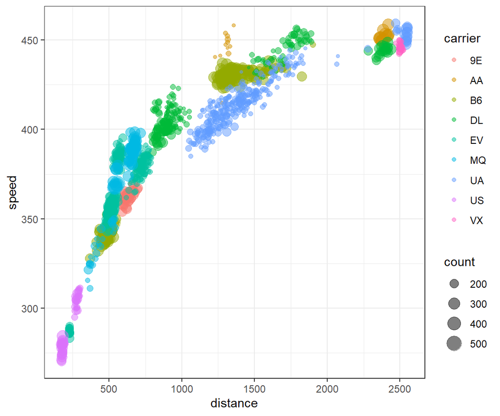

```r
#filter out canceled flights
not_cancelled <- filter(flights, !is.na(dep_time))
# add grouping variable
by_carrier <- group_by(not_cancelled, carrier, tailnum)
# add air speed column
air_speed <- mutate(by_carrier, speed = distance / air_time * 60)
# summarize data
speed_summary <- summarise(air_speed,
  count = n(),
  distance = mean(distance, na.rm = TRUE),
  speed = mean(speed, na.rm = TRUE))
# only include groups which have more than 100 observations
speed_summary <- filter(speed_summary, count > 100)

# plot the resulting data using ggplot
ggplot(speed_summary, aes(distance, speed)) + # initiate the plot
  geom_point( # add points as in a "scatterplot"
    aes(
      color = carrier,
      size = count),
    alpha = 0.5) +
  theme_bw() # I like this style better than the default
```

Not surprisingly, flights that travel a shorter distance do not reach their maximal cruising speed. The difference in speed between different carriers (colored dots) may be reflecitive of different plane models or operation procedures.

#### Practice Problems 6

Perform the following after grouping the data by `carrier`. You may want to use the `carrier_group` object created above. 1. Calculate the mean `air_time.` 2. Calculate the minimum and maximum flight `distance.` 3. Calculate the mean and standard deviation of `arr_delay.`